# data_translation_project

Tamlyn Tamura

2/18/2021

## R Markdown

Loading libraries Ctrl + Alt + I for new code chunks

Read in data

This is where I take unstructured data and try to make it a bit easier to read. I linked ‘unitid’ and ‘opeid’ to create a unique key, in case it became more organized this way down the line.

Create new data sets separated by LOCALE type–typically urbanized/city areas have a higher market rate than rural and suburban/town areas.

I was hesitant on whether or not I should include Rural Fringe, Rural Distant, and Rural Remote (41, 42, 43), since there aren’t many colleges that would be in these areas, but this actually accounts for 6448 observations, so I have decided to leave those in.

Locale median: 42300 Locale mean: 43904

Urban min: 19800, Urban median: 46600 Urban mean: 47318 Urban max: 121500

Suburban min: 17600 Suburban median: 43900 Suburban mean: 45017 Suburban max: 166200

Town min: 28900 Town median: 39900 Town mean: 41275 Town max: 68500

Rural min: 21300 Rural median: 37800 Rural mean: 37375 Rural max: 59000

Urban environments mean there are more people, more infrastructure, more businesses, and a lot more money to go around, thus raising the market rate in the local area. Despite a couple of outliers, it was expected to notice that the more urbanized a college is located, the higher the mean and medians of the salary among those who graduated 10 years before (1. Urban, 2. Suburban, 3. Town, 4. Rural).

Comparing these results to the median of total colleges across the board, I get a median 42300 USD and a mean of 43904 USD. These numbers are not too far off from the suburban mean and median, which is too be expected since there are significantly more colleges that predominantly grant bachelor’s degrees (more observations) in the urban and suburban areas, as opposed to in town and rural areas.

Since market rates in more populated areas are higher than less populated areas, I will be defining high-earning colleges as colleges located in urban and suburban areas, while low-earning colleges will be those located in town and rural areas.

When I ran the regressions separately, I noticed that all the intercepts produced statistically significant numbers, except for in the town data frame. The rural data frame produced a median salary coefficient that was significant at the .01 level. The urban and suburban areas produced median salary coefficients significant at the .001 significance level.

When I ran the regression for all index on all locales, I got the median salary to be significant at the .001 level. What was interesting is that my Adjusted R^2 is ~.002, which means that this model doesn’t tell us very much about the variation in the data, which is fair since it’s very, very rare to make the conclusion that one variable that will drive the search popularity, or index.

Since the salary coefficients for urban and suburban locales were statistically significant at the 99.9% level, then it’s safe to say that among colleges that predominantly grant bachelor’s degrees, higher-earning colleges result in more student interest. Given the negative coefficient for median salaries for colleges in rural areas, we can say we are 99% confident that among the colleges that predominantly grant bachelor’s degrees, lower-earning colleges and student interest have a negative relationship; meaning that lower-earning colleges are linked to less student interest. Additionally, we don’t have statistical significance to prove whether or not colleges in towns are linked to higher or lower student interest.

Below I used ggplot to determine if my data is normally distributed. As you can see, it looks like there are some problems in my data given the shape. One possibility could be some of the outliers, since my data ranged from as low as 17,600 USD to 166,200 USD. Another possibility is that this is not a linear relationship, and I should have used a log-linear, linear-log or log-log model to display this relationship.

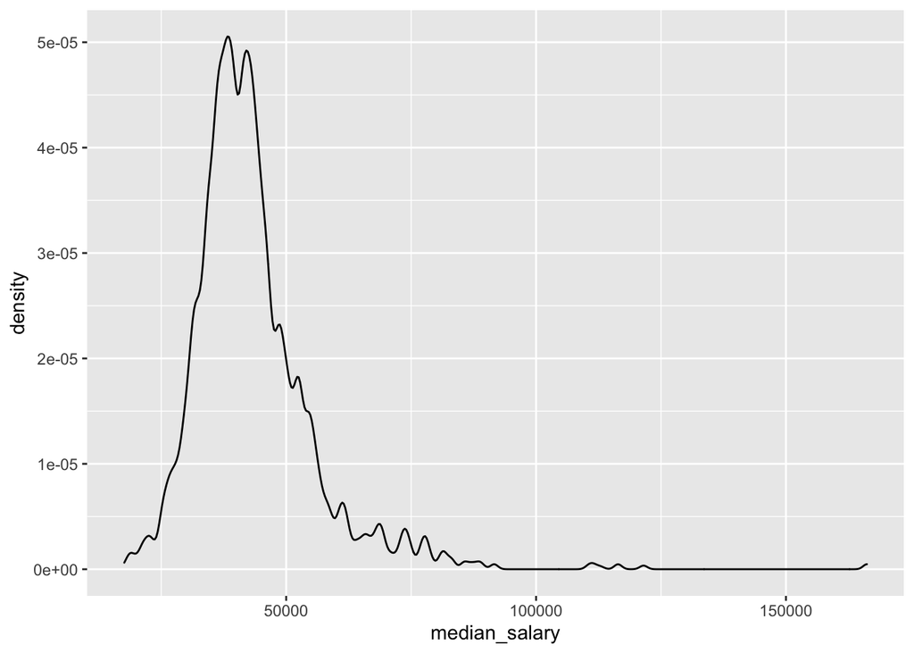

```r
g <- ggplot(locale_reg, aes(x=median_salary)) + geom_density()
print(g)
```